# Shipping Emissions

```r
library(tidyverse)
```

# Data Formatting

Monitoring Reporting Verification EU Emissions reports

Function for quick summary tables

# Import

```r
read_MRV <- function(file) {
  col_types = rep("guess", 62)
  col_types = replace(col_types, c(21,48,61), "text")
  df <- import(file,
               skip = 2,
               na = c("NA", "N/A", "Division by zero!", "Not Applicable"),
               col_types = col_types,
               setclass = "tibble")
  colnames(df) <- colnames(df) %>%
    str_to_sentence()
  return(df)
}
```

```r
MRV_df <- read_MRV("data/MRV/2018-v249-13052021-EU MRV Publication of information.xlsx")
temp_df <- read_MRV("data/MRV/2019-v163-20052021-EU MRV Publication of information.xlsx")
MRV_df <- MRV_df %>%
  bind_rows(temp_df)

temp_df <- read_MRV("data/MRV/2020-v63-05102021-EU MRV Publication of information.xlsx")
temp_df <- temp_df %>%
  rename("Annual total time spent at sea [hours]" = "Annual time spent at sea [hours]",
         "Total time spent at sea [hours]" = "Time spent at sea [hours]")

MRV_df <- MRV_df %>%
  bind_rows(temp_df)
```

Clean column names

```r
colname_descriptions <- tibble(description = colnames(MRV_df)) %>%
  mutate(description = description %>%
                    str_replace_all("\\.{3}48", "Direct emissions"),
        colname = description %>%
                    str_replace_all("\\s", "\\.") %>%
                    str_to_lower() %>%
                    str_remove_all("\\.\\[.*\\]") %>%
                    str_replace_all("fuel\\.consumptions", "fc") %>%
                    str_replace_all("fuel\\.consumption", "fc") %>%
                    str_replace_all("co.\\.emissions", "co2") %>%
                    str_replace_all("ports\\.under\\.a\\.ms\\.jurisdiction", "ms.ports") %>%
                    str_replace_all("transport\\.work", "work") %>%
                    str_remove_all("\\(") %>%
                    str_remove_all("\\)") %>%
                    str_remove_all("assigned\\.to\\.") %>%
                    str_remove_all("annual\\.average\\.") %>%
                    str_replace_all("total\\.time\\.spent", "time") %>%
                    str_replace_all("additional\\.information\\..*", "additional.info") %>%
                    str_replace_all("average\\.density\\.of\\.the\\.cargo\\.transported", "cargo.density") %>%
                    str_remove_all("from\\.all\\.voyages\\.") %>%
                    str_remove_all("departed\\.") %>%
                    str_remove_all("which\\.") %>%
                    str_remove_all("occurred\\.within\\.")
        )
```

```r
colnames(MRV_df) <- colname_descriptions$colname
MRV_df <- MRV_df %>%
  rename(ship.name = name)
```

Difference between ‘annual.time.at.sea’ and ‘time.at.sea’ ?

```r
time.col.diff <- MRV_df %>%
  mutate(time.diff = annual.time.at.sea - time.at.sea) %>%
  filter(time.diff != 0) %>%
  nrow()

if(time.col.diff == 0){
  MRV_df <- MRV_df %>%
    select(-time.at.sea) %>%
    rename(time.at.sea = annual.time.at.sea)
} else {
  warning("Difference between time at sea columns!")
}
```

Factor variables

```r
MRV_df <- MRV_df %>%
  mutate(across(c(port.of.registry,
                  home.port),
                str_to_title)) %>%
  mutate(across(c(reporting.period,
                  ship.type,
                  port.of.registry,
                  home.port,
                  ice.class),
                as_factor))
```

Numeric variables

```r
MRV_df %>%
  mutate(across(contains("fc"), as.numeric)) %>%
  mutate(across(contains("co2"), as.numeric)) %>%
  mutate(across(contains("time"), as.numeric)) %>%
  mutate(cargo.density = as.numeric(cargo.density))
```

```
## # A tibble: 36,168 × 61
##    imo.number ship.name     ship.type        reporting.period technical.efficie…
##    <chr>      <chr>         <fct>            <fct>            <chr>
##  1 5383304    ASTORIA       Passenger ship   2018             <NA>
##  2 6417097    MARCO POLO    Passenger ship   2018             <NA>
##  3 6511128    RED STAR 1    Ro-pax ship      2018             EIV (45.57 gCO₂/t…
##  4 6602898    OCEAN MAJESTY Passenger ship   2018             EIV (31.73 gCO₂/t…
##  5 6703343    EQUALITY      Other ship types 2018             <NA>
##  6 7037806    BOHUS         Ro-pax ship      2018             EIV (146 gCO₂/t·n…
##  7 7043843    TALOS         Ro-ro ship       2018             EEDI (60.41 gCO₂/…
##  8 7108930    BLACK WATCH   Passenger ship   2018             <NA>
##  9 7128332    SEA WIND      Ro-pax ship      2018             EIV (9.29 gCO₂/t·…
## 10 7128887    ST DAMIAN     Ro-pax ship      2018             EIV (41.81 gCO₂/t…
## # … with 36,158 more rows, and 56 more variables: port.of.registry <fct>,
## #   home.port <fct>, ice.class <fct>, doc.issue.date <chr>,
## #   doc.expiry.date <chr>, verifier.number <chr>, verifier.name <chr>,
## #   verifier.nab <chr>, verifier.address <chr>, verifier.city <chr>,
## #   verifier.accreditation.number <chr>, verifier.country <chr>, a <chr>,
## #   b <chr>, c <chr>, d <chr>, total.fc <dbl>, fc.on.laden <dbl>,
## #   total.co2 <dbl>, co2.between.ms.ports <dbl>, co2.from.ms.ports <dbl>, …
```

Technical efficiency

```r
MRV_df <-MRV_df %>%
  mutate(technical.efficiency = technical.efficiency %>%
                                str_remove_all("Not\\sApplicable|\\(|\\)") %>%
                                str_trim(),
         technical.efficiency = if_else(str_starts(technical.efficiency, "[:digit:]"),
                                        paste("NA", technical.efficiency),
                                        technical.efficiency)) %>%
  separate(technical.efficiency,
           c("efficiency.metric", "efficiency.value", "efficiency.unit"),
           sep = " ",
           extra = "merge",
           fill = "right",
           remove = FALSE) %>%
  mutate(efficiency.metric = na_if(efficiency.metric, "NA"),
         efficiency.value = as.numeric(efficiency.value),
         across(c(efficiency.metric, efficiency.unit), as_factor),
         EIV = if_else(efficiency.metric == "EIV", efficiency.value, NA_real_),
         EEDI = if_else(efficiency.metric == "EEDI", efficiency.value, NA_real_)) %>%
  select(-technical.efficiency) %>%
  rename(technical.efficiency = efficiency.value)
```

Distance travelled, speed, emission factor

```r
MRV_df <- MRV_df %>%
  mutate(EU.distance = total.fc / fc.per.distance * 1E3) %>%
  mutate(speed = EU.distance / time.at.sea) %>%
  mutate(emission.factor = total.co2 / total.fc)
```

```r
save(MRV_df, file = "data/MRV.Rda")
```

## Inspect

```r
MRV_df %>%
  filter(ship.type == "Bulk carrier") %>%
  View()
```

Completeness

```r
MRV_df %>%
  summary()
```

```
##   imo.number         ship.name                      ship.type
##  Length:36168       Length:36168       Bulk carrier      :10798
##  Class :character   Class :character   Oil tanker        : 5758
##  Mode  :character   Mode  :character   Container ship    : 5459
##                                        Chemical tanker   : 4045
##                                        General cargo ship: 3597
##                                        Vehicle carrier   : 1333
##                                        (Other)           : 5178
##  reporting.period efficiency.metric technical.efficiency  efficiency.unit
##  2018:12178       EIV :24103        Min.   :    0.00     gCO₂/t·nm:32422
##  2019:12307       EEDI: 8192        1st Qu.:    4.51     NA's     : 3746
##  2020:11683       NA's: 3873        Median :    7.08
##                                     Mean   :   12.31
##                                     3rd Qu.:   14.48
##                                     Max.   :12700.00
##                                     NA's   :3746
##   port.of.registry     home.port         ice.class     doc.issue.date
##  Majuro   : 4508   Monrovia :  979   IA       : 3307   Length:36168
##  Monrovia : 4332   Majuro   :  689   IC       : 1588   Class :character
##  Panama   : 3928   Valletta :  541   IB       :  629   Mode  :character
##  Valletta : 2785   Singapore:  465   IA Supper:  364
##  Singapore: 1910   Panama   :  437   PC1      :  114
##  (Other)  :15382   (Other)  : 3666   (Other)  :  156
##  NA's     : 3323   NA's     :29391   NA's     :30010
##  doc.expiry.date    verifier.number    verifier.name      verifier.nab
##  Length:36168       Length:36168       Length:36168       Length:36168
##  Class :character   Class :character   Class :character   Class :character
##  Mode  :character   Mode  :character   Mode  :character   Mode  :character
##
##
##
##
##  verifier.address   verifier.city      verifier.accreditation.number
##  Length:36168       Length:36168       Length:36168
##  Class :character   Class :character   Class :character
##  Mode  :character   Mode  :character   Mode  :character
##
##
##
##
```

[output cut: 121 more lines]

```
##  Min.   :    0.00   Min.   :   0.000   Min.   :    12.86   Min.   : 0.000
##  1st Qu.:    5.35   1st Qu.:   3.697   1st Qu.: 12086.57   1st Qu.: 9.402
##  Median :    8.12   Median :   4.740   Median : 22920.72   Median :11.165
##  Mean   :   13.62   Mean   :   8.624   Mean   : 28914.73   Mean   :   Inf
##  3rd Qu.:   16.29   3rd Qu.:   8.210   3rd Qu.: 39609.34   3rd Qu.:12.816
##  Max.   :12700.00   Max.   :5856.000   Max.   :313736.05   Max.   :   Inf
##  NA's   :12072      NA's   :27984      NA's   :1359        NA's   :1359
##  emission.factor
##  Min.   : 1.030
##  1st Qu.: 3.124
##  Median : 3.134
##  Mean   : 3.137
##  3rd Qu.: 3.151
##  Max.   :30.092
##  NA's   :1351
```

## Summary

```r
MRV_df %>%
  select(-starts_with("verifier")) %>%
  group_by(reporting.period, ship.type) %>%
  mutate(across(everything(), ~{!is.na(.x)})) %>%
  summarise(across(everything(), sum)) %>%
  # arrange(ship.type)
  filter(ship.type == "Bulk carrier")
```

World Fleet Register

```r
library(tidyverse)
# library(rio)
library(lubridate)
library(forcats)
library(utils)
```

# Bulkers

## Fleet database

```r
read_WFR_varset <- function(shiptype, varset, col_types){
  fleet_files <- list.files("data/WFR/") %>%
    str_subset(paste0("WFR_", shiptype)) %>%
    str_subset(paste0("Vars", varset))

  fleet_df <- tibble()
  for(filename in fleet_files){
    print(filename)
    temp_df <- read.csv(file.path("data/WFR", filename),
                      skip = 6,
                      header = TRUE,
                      colClasses = col_types,
                      blank.lines.skip = TRUE,
                      fill = TRUE
                      # nrows = nrow
                      ) %>%
      as_tibble(.name_repair = 'universal') %>%
      filter(!str_detect(.[[1]], "Clarkson Research Services"))

    fleet_df <- bind_rows(fleet_df, temp_df)
  }

  save(fleet_df, file = paste0("data/", shiptype, "_vars", varset, ".Rda"))
}
```

```r
col_types <- rep("character", 40)
col_types[c(2, 4, 13, 14, 16, 17, 18, 20, 23, 25, 29, 30, 31, 34, 35, 36, 37)] <- "numeric"
read_WFR_varset("Bulkers", 1, col_types)
```

```
## [1] "WFR_Bulkers_1958-2009_Vars1.csv"
## [1] "WFR_Bulkers_2010-2013_Vars1.csv"
## [1] "WFR_Bulkers_2014-2025_Vars1.csv"
```

```r
col_types <- rep("character", 40)
col_types[c(2, 7, 8, 10, 12, 13, 15, 16, 17, 22, 23, 25, 27)] <- "numeric"
read_WFR_varset("Bulkers", 2, col_types)
```

```
## [1] "WFR_Bulkers_1958-2009_Vars2.csv"
## [1] "WFR_Bulkers_2010-2013_Vars2.csv"
## [1] "WFR_Bulkers_2014-2025_Vars2.csv"
```

```r
col_types <- rep("character", 40)
col_types[c(2, 4, 5, 12, 13, 15, 17, 20, 21, 22, 23, 32:37)] <- "numeric"
read_WFR_varset("Bulkers", 3, col_types)
```

```
## [1] "WFR_Bulkers_1958-2009_Vars3.csv"
## [1] "WFR_Bulkers_2010-2013_Vars3.csv"
## [1] "WFR_Bulkers_2014-2025_Vars3.csv"
```

```r
col_types <- rep("character", 40)
col_types[c(3, 9, 19, 20, 21, 29, 30, 34:38)] <- "numeric"
read_WFR_varset("Bulkers", 4, col_types)
```

```
## [1] "WFR_Bulkers_1958-2009_Vars4.csv"
## [1] "WFR_Bulkers_2010-2013_Vars4.csv"
## [1] "WFR_Bulkers_2014-2025_Vars4.csv"
```

```r
col_types <- rep("character", 40)
col_types[c(2, 7, 13:28, 29:34, 38, 40)] <- "numeric"
read_WFR_varset("Bulkers", 5, col_types)
```

```
## [1] "WFR_Bulkers_1958-2009_Vars5.csv"
## [1] "WFR_Bulkers_2010-2013_Vars5.csv"
## [1] "WFR_Bulkers_2014-2025_Vars5.csv"
```

### Merge variable sets

```r
load("data/Bulkers_vars1.Rda")
bulkers_df <- fleet_df %>%
  mutate(across(c(Built.Date, Keel.Laid.Date, Contract.Date, Demo.Date), dmy),
         IMO.Number = as.numeric(IMO.Number),
         CVN = as.numeric(CVN)) %>%
  rename(MMSI = MMSI..Maritime.Mobile.Service.Identity.,
         Demo.Price.LDT = Demo...LDT,
         Beam.Mid..m = Beam.Mld..m.) %>%
  mutate(Built.Year = year(Built.Date), .after = Built.Date) %>%
  mutate(Size.Category = cut(Dwt,
                             breaks = c(0, 10000, 40000, 60000, 100000, Inf),
                             right = FALSE,
                             labels = c("Small",
                                        "Handysize",
                                        "Handymax",
                                        "Panamax",
                                        "Capesize")),
         .after = Dwt)
# Categories as per Kalouptsidi (2014). Note Clarkson has cutoff at 70k rather than 60k.
assign(paste0("bulkers_vars1_df"), bulkers_df)
```

```r
load("data/Bulkers_vars2.Rda")
bulkers_df <- fleet_df %>%
  mutate(across(c(Built.Date, Launch.Date, SOx.Scrubber.1.Retrofit.Date), dmy),
         CVN = as.numeric(CVN)) %>%
  select(-c(IMO.Number, Name, Built.Date, Owner))

assign(paste0("bulkers_vars2_df"), bulkers_df)
```

```r
load("data/Bulkers_vars3.Rda")
bulkers_df <- fleet_df %>%
  mutate(across(c(Hull.Survey.Due.Date, Last.Hull.Survey.Date), dmy),
         CVN = as.numeric(CVN))

assign(paste0("bulkers_vars3_df"), bulkers_df)
```

```r
load("data/Bulkers_vars4.Rda")
bulkers_df <- fleet_df %>%
  mutate(across(c(Vessel.Name.Date, BWMS.1.Retrofit.Date, BWMS.2.Retrofit.Date), dmy),
         CVN = as.numeric(CVN)) %>%
  select(-Propulsor.Detail)

assign(paste0("bulkers_vars4_df"), bulkers_df)
```

```r
load("data/Bulkers_vars5.Rda")
bulkers_df <- fleet_df %>%
  mutate(CVN = as.numeric(CVN))

assign(paste0("bulkers_vars5_df"), bulkers_df)
```

```r
bulkers_df <- bulkers_vars1_df %>%
  full_join(bulkers_vars2_df, by = "CVN") %>%
  full_join(bulkers_vars3_df, by = "CVN") %>%
  full_join(bulkers_vars4_df, by = "CVN") %>%
  full_join(bulkers_vars5_df, by = "CVN")
```

### Tidy

```r
bulkers_df <- bulkers_df %>%
  mutate(Owner.Size = trimws(Owner.Size),
         Owner.Size = replace(Owner.Size,
                              Owner.Size == "Very Large(51-100)",
                              "Very Large (51-100)"))
```

```r
save(bulkers_df, file = "data/bulkers_WFR.Rda")
```

# Containerships

## Fleet database

```r
col_types <- rep("character", 40)
col_types[c(2, 4, 13, 14, 16, 17, 18, 20, 23, 25, 29, 30, 31, 34, 35, 36, 37)] <- "numeric"
read_WFR_varset("Containerships", "C1", col_types)
```

```
## [1] "WFR_Containerships_1969-1998_VarsC1.csv"
## [1] "WFR_Containerships_1999-2021_VarsC1.csv"
```

Note: quotations within Registered.Owner.Company had to be fixed manually before reading

Replaced open and closing quotations with ” as well as ’ with “, then fixing ones that should have remaind ’

```r
col_types <- rep("character", 37)
col_types[c(3, 4, 6, 7, 8, 10, 11, 12, 15, 16, 18, 20, 33, 35)] <- "numeric"
read_WFR_varset("Containerships", "C2", col_types)
```

```
## [1] "WFR_Containerships_1969-1998_VarsC2.csv"
## [1] "WFR_Containerships_1999-2021_VarsC2.csv"
```

```r
# for(nrow in seq(from = 4280, to = 5000, by = 1)){
#   print(nrow)
#   read_WFR_varset("Containerships", "C22", col_types, nrow)
# }
```

```r
col_types <- rep("character", 40)
col_types[c(2, 8, 9, 11, 13, 16:19, 27:32)] <- "numeric"
read_WFR_varset("Containerships", "C3", col_types)
```

```
## [1] "WFR_Containerships_1969-1998_VarsC3.csv"
## [1] "WFR_Containerships_1999-2021_VarsC3.csv"
```

```r
col_types <- rep("character", 40)
col_types[c(3, 8, 12:14, 24:27, 30:32, 37, 38)] <- "numeric"
read_WFR_varset("Containerships", "C4", col_types)
```

```
## [1] "WFR_Containerships_1969-1998_VarsC4.csv"
## [1] "WFR_Containerships_1999-2021_VarsC4.csv"
```

```r
col_types <- rep("character", 37)
col_types[c(8:28, 30, 32, 34:36)] <- "numeric"
read_WFR_varset("Containerships", "C5", col_types)
```

```
## [1] "WFR_Containerships_1969-1998_VarsC5.csv"
## [1] "WFR_Containerships_1999-2021_VarsC5.csv"
```

### Merge variable sets

```r
load("data/Containerships_varsC1.Rda")
containerships_df <- fleet_df %>%
  mutate(across(contains("Date"), dmy),
         IMO.Number = as.numeric(IMO.Number),
         CVN = as.numeric(CVN)) %>%
  rename(MMSI = MMSI..Maritime.Mobile.Service.Identity.,
         Demo.Price.LDT = Demo...LDT,
         Beam.Mid..m = Beam.Mld..m.) %>%
  mutate(Built.Year = year(Built.Date), .after = Built.Date)

assign(paste0("containerships_vars1_df"), containerships_df)
```

```r
load("data/Containerships_varsC2.Rda")
containerships_df <- fleet_df %>%
  mutate(across(contains("Date"), dmy),
         CVN = as.numeric(CVN)) %>%
  mutate(Size.Category = cut(TEU,
                             breaks = c(0, 3000, 8000, 17000, Inf),
                             right = FALSE,
                             labels = c("Feeder",
                                        "Intermediate",
                                        "Neopanamax",
                                        "Postpanamax")),
         .after = TEU)
# Size categories based on SIN fleet download categories
assign(paste0("containerships_vars2_df"), containerships_df)
```

```r
load("data/Containerships_varsC3.Rda")
containerships_df <- fleet_df %>%
  mutate(across(contains("Date"), dmy),
         CVN = as.numeric(CVN))

assign(paste0("containerships_vars3_df"), containerships_df)
```

```r
load("data/Containerships_varsC4.Rda")
containerships_df <- fleet_df %>%
  mutate(across(contains("Date") & !contains("Ind"), dmy),
         CVN = as.numeric(CVN))

assign(paste0("containerships_vars4_df"), containerships_df)
```

```r
load("data/Containerships_varsC5.Rda")
containerships_df <- fleet_df %>%
  mutate(across(contains("Date"), dmy),
         CVN = as.numeric(CVN))

assign(paste0("containerships_vars5_df"), containerships_df)
```

```r
containerships_df <- containerships_vars1_df %>%
  full_join(containerships_vars2_df, by = "CVN") %>%
  full_join(containerships_vars3_df, by = "CVN") %>%
  full_join(containerships_vars4_df, by = "CVN") %>%
  full_join(containerships_vars5_df, by = "CVN")
```

### Tidy

```r
containerships_df <- containerships_df %>%
  mutate(Owner.Size = trimws(Owner.Size),
         Owner.Size = replace(Owner.Size,
                              Owner.Size == "Very Large(51-100)",
                              "Very Large (51-100)"))
```

```r
save(containerships_df, file = "data/containerships_WFR.Rda")
```

# Data Joining

```r
library(tidyverse)
options(dplyr.summarise.inform = FALSE)
# library(feather)
```

# Load data

```r
load("data/bulkers_WFR.Rda")
load("data/containerships_WFR.Rda")
# ais_mmsi <- read.csv("data/ais_mmsi.csv") %>%
#   as_tibble(.name_repair = 'universal') %>%
#   rename(AIS.MMSI = mmsi)
# ais_yearly_distance <- read_feather("data/AIS_yearly_distance.feather") %>%
#   as_tibble(.name_repair = 'universal')
AIS_df <- read.csv("data/AIS_yearly_distance.csv") %>%
  as_tibble(.name_repair = 'universal') %>%
  rename(MMSI = mmsi)
# load("data/ais_mmsi.Rda")
load("data/MRV.Rda")
```

Harmonize types

```r
bulkers_df <- bulkers_df %>%
  mutate(IMO.Number = as.integer(IMO.Number))

containerships_df <- containerships_df %>%
  mutate(IMO.Number = as.integer(IMO.Number))

MRV_df <- MRV_df %>%
  mutate(imo.number = as.integer(imo.number))
```

# EIV Calculations

## Bulkers

```r
bulkers_df <- bulkers_df %>%
  mutate(Main.Engine.Power.kW = str_remove_all(Main.Engine.Detail, ",") %>%
                             str_extract("\\b\\d*(?=mkW\\stotal)") %>%
                             as.integer(),
         Auxiliary.Engine.Power.kW = str_remove_all(Auxiliary.Engine.Detail, ",") %>%
                             str_extract("\\b\\d*(?=mkW\\stotal)") %>%
                             as.integer()) %>%
  mutate(PAE = if_else(Main.Engine.Power.kW >= 10000, 0.025 * Main.Engine.Power.kW + 250, 0.05 * Main.Engine.Power.kW),
         Design.Efficiency = Main.Engine.Power.kW*Main.Consumption.at.Service.Speed..tpd../(Dwt*Service.Speed..knots.),
         EIV.Calculated = 3.1144 * (190 * 0.75 * Main.Engine.Power.kW + 215 * PAE)/(Dwt*Service.Speed..knots.),
         EIV.Main.Calculated = 3.1144 * (190 * 0.75 * Main.Engine.Power.kW)/(Dwt*Service.Speed..knots.))
```

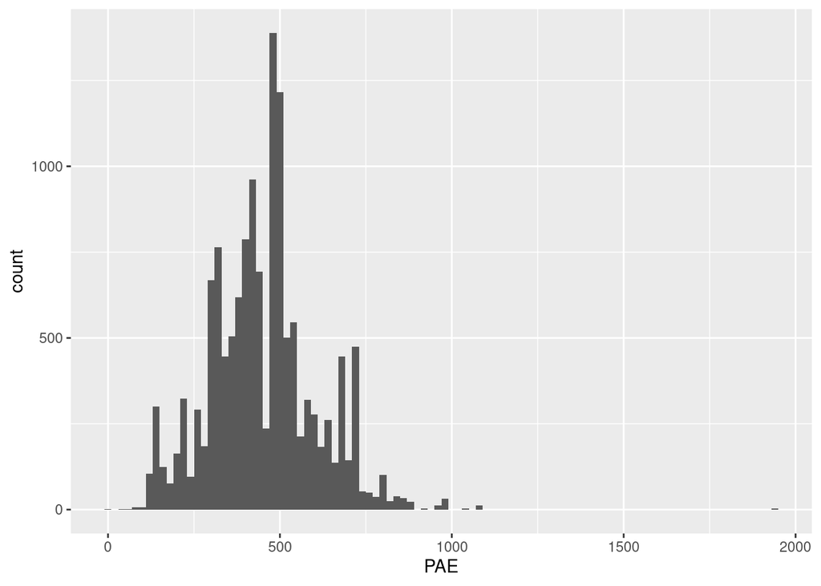

```r
bulkers_df %>%
  ggplot(aes(PAE)) +
  geom_histogram(binwidth = 20)
```

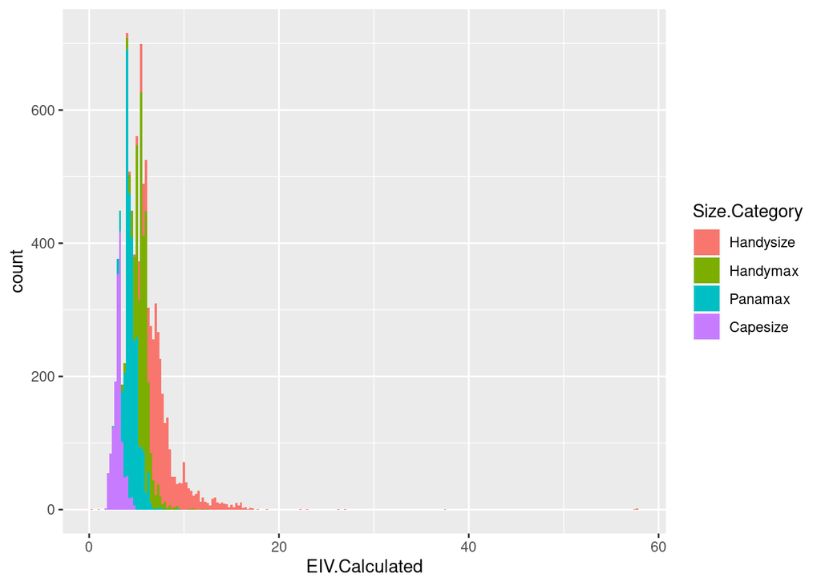

```r
bulkers_df %>%
  ggplot(aes(x = EIV.Calculated, fill = Size.Category)) +
  geom_histogram(binwidth = 0.25)
```

# Combine bulkers and container ships

```r
fleet_df <- bind_rows(bulkers_df, containerships_df)
```

## Reorganize

```r
fleet_df <- fleet_df %>%
  relocate(Fleet.Type, .before = CVN) %>%
  relocate(c(Size.Category, Dwt), .after = MMSI) %>%
  relocate(Type, .before = Size.Category) %>%
  # relocate(Dwt, .after = Size.Category) %>%
  relocate(c(Built.Date, Built.Year), .after = Dwt) %>%
  relocate(Alternative.Name, .after = Name) %>%
  relocate(Ex.Name, .after = Alternative.Name) %>%
  relocate(Owner.Size, .after = Owner) %>%
  relocate(Design.Efficiency, .after = Group.Owner) %>%
  relocate(contains("EIV"), .after = Design.Efficiency)
```

# WFR-AIS

```r
colnames(AIS_df) <- paste0('AIS.', colnames(AIS_df))
```

```r
AIS_df <- AIS_df %>%
  arrange(AIS.year) %>%
  pivot_wider(names_from = AIS.year,
              names_prefix = "AIS.Distance.",
              values_from = AIS.distance,)
```

## join

```r
fleet_df <- fleet_df %>%
  left_join(AIS_df,
            by = c("MMSI" = "AIS.MMSI"),
            keep = TRUE) %>%
  relocate(AIS.MMSI, .after = MMSI) %>%
  relocate(contains("Distance"), .after = Group.Owner)
```

How many ships in WFR don’t have tracking data?

```r
fleet_df %>%
  drop_na(MMSI) %>%
  group_by(is.na(AIS.MMSI)) %>%
  summarise(n())
```

```
## # A tibble: 2 × 2
##   `is.na(AIS.MMSI)` `n()`
##   <lgl>             <int>
## 1 FALSE             12720
## 2 TRUE               6063
```

Which ships don’t have tracking data?

```r
fleet_df %>%
  drop_na(MMSI) %>%
  group_by(Fleet.Type, is.na(AIS.MMSI), Status) %>%
  summarise(n())
```

```
## # A tibble: 38 × 4
## # Groups:   Fleet.Type, is.na(AIS.MMSI) [4]
##    Fleet.Type `is.na(AIS.MMSI)` Status                 `n()`
##    <chr>      <lgl>             <chr>                  <int>
##  1 Bulkers    FALSE             Damaged/Not in Service     1
##  2 Bulkers    FALSE             Dead/Demolished          242
##  3 Bulkers    FALSE             Dedicated Storage          6
##  4 Bulkers    FALSE             Idle                    1026
##  5 Bulkers    FALSE             In Service             11344
##  6 Bulkers    FALSE             Laid Up                    1
##  7 Bulkers    FALSE             Miscellaneous Removal     17
##  8 Bulkers    FALSE             On Order                   1
##  9 Bulkers    FALSE             Repairs                   45
## 10 Bulkers    FALSE             Storage                    3
## # … with 28 more rows
```

Only missing 185 in-service bulkers! There is some mislabeling or maybe transferred tracking devices, but it’s in the very low tens.

Which tracked ships aren’t in fleet register?

```r
unmatched_ais_df <- anti_join(AIS_df, fleet_df,
                              by = c("AIS.MMSI" = "MMSI"))
```

This will be empty because I used the fleet register to subset AIS data.

```r
AIS_df %>%
  arrange(desc(AIS.MMSI)) %>%
  View()
```

# WFR-MRV

```r
MRV_df %>% colnames()
```

```r
MRV_wide_df <- MRV_df %>%
  select(IMO.Number = imo.number,
         Ship.Name = ship.name,
         Ship.Type = ship.type,
         Technical.Efficiency = technical.efficiency,
         Efficiency.Metric = efficiency.metric,
         EEDI,
         EIV,
         Reporting.Period = reporting.period,
         Total.FC = total.fc,
         Total.CO2 = total.co2,
         Time.At.Sea = time.at.sea,
         Speed = speed,
         EU.Distance = EU.distance,
         Emission.Factor = emission.factor,
         FC.On.Laden = fc.on.laden,
         FC.Per.Distance = fc.per.distance,
         FC.Per.Work.Mass = fc.per.work.mass,
         FC.Per.Work.Mass.On.Laden.Voyages = fc.per.work.mass.on.laden.voyages,
         FC.Per.Work.Volume.On.Laden.Voyages = fc.per.work.volume.on.laden.voyages) %>%
  arrange(IMO.Number, Reporting.Period) %>%
  pivot_wider(id_cols = c(IMO.Number),
              names_from = Reporting.Period,
              values_from = -c(IMO.Number, Reporting.Period),
              names_sep = ".")

colnames(MRV_wide_df) <- paste0('MRV.', colnames(MRV_wide_df))
```

Can I reduce design efficiency metrics to single variable? How many ships report the same efficiency year on year?

```r
MRV_wide_df %>%
  mutate(MRV.Constant.Efficiency.Metric =
           MRV.Efficiency.Metric.2018 == MRV.Efficiency.Metric.2019 &
           MRV.Efficiency.Metric.2019 == MRV.Efficiency.Metric.2020,
         MRV.Constant.Efficiency =
           MRV.Technical.Efficiency.2018 - MRV.Technical.Efficiency.2019 < 1 &
           MRV.Technical.Efficiency.2019 - MRV.Technical.Efficiency.2020 < 1,) %>%
  group_by(MRV.Constant.Efficiency.Metric, MRV.Constant.Efficiency) %>%
  # filter(constant.efficiency.metric, !constant.efficiency) %>%
  summarise(n())
```

```
## # A tibble: 9 × 3
## # Groups:   MRV.Constant.Efficiency.Metric [3]
##   MRV.Constant.Efficiency.Metric MRV.Constant.Efficiency `n()`
##   <lgl>                          <lgl>                   <int>
## 1 FALSE                          FALSE                     127
## 2 FALSE                          TRUE                      132
## 3 FALSE                          NA                         63
## 4 TRUE                           FALSE                     374
## 5 TRUE                           TRUE                     4719
## 6 TRUE                           NA                          4
## 7 NA                             FALSE                     176
## 8 NA                             TRUE                       82
## 9 NA                             NA                      10985
```

Leave as-is for now.

## join

```r
fleet_df <- fleet_df %>%
  left_join(MRV_wide_df,
            by = c("IMO.Number" = "MRV.IMO.Number"),
            keep = TRUE) %>%
  relocate(MRV.IMO.Number, .after = IMO.Number) %>%
  relocate(contains("MRV.Ship.Name."), .after = Name) %>%
  relocate(contains("MRV.Ship.Type."), .after = Type) %>%
  relocate(contains("EU.Distance"), .after = AIS.Distance.2021) %>%
  relocate(contains("EIV"), .after = Design.Efficiency) %>%
  relocate(contains("EEDI"), .after = MRV.EIV.2020)
```

How many WFR ships report in MRV?

```r
fleet_df %>%
  select(CVN,
         IMO.Number,
         MRV.IMO.Number,
         Name,
         starts_with("MRV.Ship.Name."),
         Type,
         starts_with("MRV.Ship.Type.")) %>%
  drop_na(IMO.Number) %>%
  group_by(is.na(MRV.IMO.Number)) %>%
  summarise(count = n()) %>%
  mutate(percentage = count / sum(count) * 100)
```

```
## # A tibble: 2 × 3
##   `is.na(MRV.IMO.Number)` count percentage
##   <lgl>                   <int>      <dbl>
## 1 FALSE                    8337       44.0
## 2 TRUE                    10618       56.0
```

44% of ships report in MRV. This is quite high!

```r
fleet_df %>%
  select(CVN,
         IMO.Number,
         MRV.IMO.Number,
         Name,
         starts_with("MRV.Ship.Name."),
         Type,
         starts_with("MRV.Ship.Type.")) %>%
  filter(!is.na(MRV.IMO.Number)) %>%
  View()
```

How does fleet type compare between WFR and MRV?

```r
fleet_df %>%
  group_by(Fleet.Type, MRV.Ship.Type.2020) %>%
  summarise(n())
```

```
## # A tibble: 10 × 3
## # Groups:   Fleet.Type [2]
##    Fleet.Type     MRV.Ship.Type.2020  `n()`
##    <chr>          <fct>               <int>
##  1 Bulkers        Other ship types       22
##  2 Bulkers        Bulk carrier         3306
##  3 Bulkers        General cargo ship    232
##  4 Bulkers        Container ship          1
##  5 Bulkers        Combination carrier     1
##  6 Bulkers        <NA>                10493
##  7 Containerships General cargo ship     18
##  8 Containerships Container ship       1825
##  9 Containerships Combination carrier     1
## 10 Containerships <NA>                 4041
```

Fairly good correspondence, though MRV has many missings.

# WFR-AIS-MRV

```r
fleet_df %>%
  group_by(Fleet.Type, is.na(AIS.MMSI), is.na(MRV.IMO.Number)) %>%
  summarise(n())
```

# Save

```r
save(fleet_df, file = "data/All_join.Rda")
```

# Exploration of composite dataset